# Entorno Económico y Financiero para las Decisiones de Inversión

Clase 03: Modelo Keynesiano, consumo e IS-LM

octubre 2026

# Presentación del curso

## Equipo docente

**Docentes:**

- Sebastián Egaña Santibáñez
- Felipe Jaque

**Ayudante:**

- Jean Pierre Bravo

## Contenidos del curso

- Análisis de principales variables macroeconómicas
- Políticas macroeconómicas
- Revisión de modelos de mercado de bienes y de activos financieros
- Comportamiento de los agentes económicos: consumo y gobierno

## Sobre el docente

**Sebastián Egaña Santibáñez**

- Data Tech Lead & Analytics Translator — LATAM Airlines
- Correo: segana@fen.uchile.cl
- Web: https://segana.netlify.app
- LinkedIn: [enlace](https://www.linkedin.com/in/sebastian-egana-santibanez/)

## Hilo conductor de la clase

Partimos con una pregunta. Al terminar la sesión deberían poder responderla con precisión.

“Los aranceles de Trump generan una guerra comercial: ¿puede Chile reaccionar con política fiscal o monetaria? ¿Funciona igual en economía cerrada que abierta?”

Para responderla necesitamos entender cómo el gasto del gobierno amplifica el producto (multiplicador), cómo la tasa de interés conecta el mercado de bienes con el monetario (IS-LM) y por qué en economía abierta las respuestas cambian radicalmente.

## ¿Qué veremos esta clase?

| Bloque | Conceptos clave |
| --- | --- |
| Modelo Keynesiano Simple | Demanda agregada, función de consumo, multiplicador |
| La curva IS | Mercado de bienes en equilibrio, pendiente, desplazamientos |
| La curva LM | Mercado monetario en equilibrio, pendiente, desplazamientos |
| Equilibrio IS-LM | Política monetaria, política fiscal, policy mix |

> Lecturas complementarias: comportamiento del consumidor (`clase03_lectura_02_consumo`) y economía abierta / Mundell-Fleming (`clase03_lectura_01_mundell_fleming`)

# Modelo Keynesiano Simple

## Planteamiento inicial

Partimos con el supuesto de **economía cerrada**: no existen transacciones con el mercado internacional.

La **demanda agregada** bajo economía cerrada es:

$$A = C + I + G$$

donde $I$ y $G$ (inversión y gasto de gobierno) se asumen **exógenos** (constantes por ahora).

El **consumo** viene determinado por:

$$C = \bar{C} + c(Y - T)$$

donde $\bar{C}$ es el consumo autónomo, $c$ es la propensión marginal a consumir ($0 < c < 1$), $Y$ es el ingreso y $T$ son los impuestos.

## Equilibrio del mercado de bienes

En equilibrio, el producto igual a la demanda agregada: $Y = A$

Sustituyendo la función de consumo:

$$Y = \bar{C} + c(Y - T) + I + G$$

Despejando $Y$:

$$Y = \frac{1}{1 - c}\left(\bar{C} - cT + I + G\right)$$

El término $\frac{1}{1-c}$ es el **multiplicador keynesiano**. Como $0 < c < 1$, se tiene que $\frac{1}{1-c} > 1$.

## El multiplicador

Con impuestos proporcionales al ingreso ($T = \tau Y$), el equilibrio del mercado de bienes es:

$$Y^* = \frac{1}{1 - c(1-\tau)}\left(\bar{C} + I + G\right)$$

El **multiplicador del gasto** es:

$$\frac{\partial Y}{\partial G} = \frac{\partial Y}{\partial I} = \frac{\partial Y}{\partial \bar{C}} = \frac{1}{1 - c(1-\tau)} > 1$$

## El multiplicador

Un aumento de $1 en el gasto público genera un aumento en el producto **mayor que $1**. ¿Por qué? El dinero circula:

**Ejemplo:** el gobierno compra libros para los colegios públicos ($\uparrow G$)

1. La editorial recibe ingresos → paga sueldos a editores, impresores, diseñadores
2. Esas personas tienen más ingreso disponible → consumen una fracción $c$ de ese ingreso
3. Ese consumo genera ingresos a otras empresas → que pagan más sueldos → que generan más consumo
4. El proceso se repite, pero cada ronda es más pequeña (la fracción $1-c$ se ahorra)

El total acumulado de todas las rondas es el **multiplicador**: $\frac{1}{1-c(1-\tau)}$

## ¿Por qué el multiplicador importa hoy?

Si Chile enfrenta una caída en exportaciones por los aranceles de Trump, el gobierno podría intentar compensarla con mayor gasto ($\uparrow G$).

El modelo Keynesiano simple predice:

$$\Delta Y = \frac{1}{1 - c(1-\tau)} \cdot \Delta G$$

Con $c = 0{,}8$ y $\tau = 0{,}2$: el multiplicador es $\frac{1}{1 - 0{,}8 \times 0{,}8} = \frac{1}{0{,}36} \approx 2{,}8$

**Problema:** Este modelo supone economía cerrada. En economía abierta con movilidad de capitales, el multiplicador es muy distinto — y esa es la pregunta que responderemos al final.

# Comportamiento del Consumidor

## Más allá del modelo keynesiano

La función $C = \bar{C} + c(Y-T)$ es una simplificación útil pero tiene un límite importante: no considera cómo las personas planifican su consumo a lo largo del tiempo.

Las dos teorías que extienden este modelo tienen implicancias directas sobre la efectividad del multiplicador fiscal:

| Teoría | Autor | Predicción clave |
| --- | --- | --- |
| Ciclo de vida | Modigliani | Las personas suavizan consumo a lo largo de su vida |
| Ingreso permanente | Friedman | Solo los cambios permanentes en ingreso afectan el consumo |

> Desarrollo completo en `clase03_lectura_02_consumo`

# La Tasa de Interés y el Mercado de Bienes (IS)

## La curva IS

Hasta ahora, la inversión $I$ era exógena. En realidad, la inversión **depende negativamente de la tasa de interés real** $r$: financiarse es más caro cuando $r$ sube.

La condición de equilibrio del mercado de bienes pasa a ser:

$$IS: \quad Y = \bar{C} + c(Y - T) + I(r) + G$$

La curva IS es el **conjunto de combinaciones $(r, Y)$** para las cuales el mercado de bienes está en equilibrio, es decir, $Y = DA$.

**Supuesto clave:** los precios son fijos — las empresas venden todo lo que se demanda sin cambiar precios (mundo keynesiano de corto plazo).

## Pendiente de la IS

La IS tiene **pendiente negativa** en el plano $(r, Y)$:

- $\uparrow r$ → $\downarrow I(r)$ → menor demanda de bienes
- Menor demanda → empresas acumulan inventarios → reducen producción
- $\downarrow Y$

Intuición: tasas más altas incentivan el ahorro en vez del gasto. Las empresas venden menos, acumulan inventarios y recortan producción.

**Desplazamientos de la IS:**

| Variable exógena sube | Efecto |
| --- | --- |
| $\uparrow G$ | IS se desplaza **a la derecha** |
| $\downarrow T$ | IS se desplaza **a la derecha** |
| $\uparrow \bar{C}$ | IS se desplaza **a la derecha** |

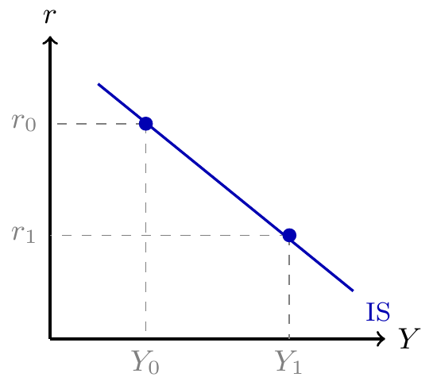

Una baja en $r$ de $r_0$ a $r_1$ → $I$ sube → $Y$ sube de $Y_0$ a $Y_1$

Un aumento de $G$ desplaza la IS completa hacia la derecha.

## Derivación: del Keynesiano a la IS

La IS es el modelo Keynesiano simple **con inversión sensible a la tasa**. La diferencia:

| Modelo Keynesiano simple | Curva IS |
| --- | --- |
| $I$ exógena (constante) | $I = I(r)$ — función decreciente de $r$ |
| Equilibrio: un único $Y^*$ | Equilibrio: una curva de pares $(r, Y)$ |
| No interactúa con el mercado monetario | Interactúa con la LM → equilibrio macroeconómico |

Cada punto sobre la IS representa un equilibrio del mercado de bienes para una tasa de interés dada. El modelo no está completo hasta agregar el mercado monetario.

# El Mercado Monetario (LM)

## La curva LM

> ¿Qué tasa de interés equilibra el mercado del dinero cuando la economía crece?

En la Clase 02 vimos que el BCCh usa la TPM para influir en la tasa de interés nominal. La curva LM **formaliza exactamente ese mecanismo**: para cada nivel de ingreso $Y$, indica qué tasa $i$ equilibra oferta y demanda de dinero.

## La curva LM

**Demanda de dinero** — positiva en $Y$ (más transacciones) y negativa en $i$ (mayor costo de oportunidad de mantener efectivo):

$$\frac{M^d}{P} = L(i, Y) \quad \text{con } \frac{\partial L}{\partial i} < 0, \quad \frac{\partial L}{\partial Y} > 0$$

**Oferta de dinero** — fija, controlada por el BCCh. En equilibrio:

$$LM: \quad \frac{\bar{M}}{P} = L(i, Y)$$

## Derivando la curva LM

La LM es el conjunto de equilibrios del mercado monetario para distintos niveles de $Y$. Para construirla, fijamos $\bar{M}/P$ y preguntamos: ¿qué $i$ equilibra oferta y demanda de dinero cuando $Y$ cambia?

**Mercado monetario** — plano $(M/P,\, i)$

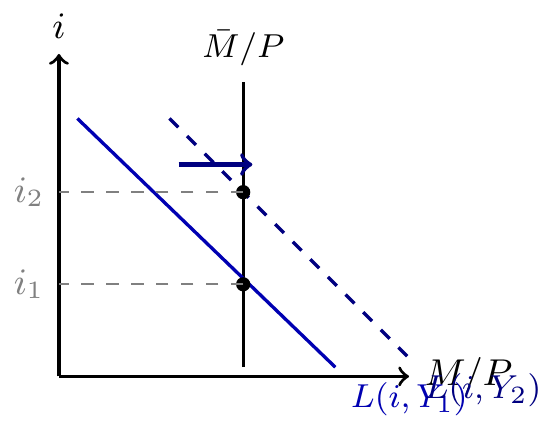

**LM resultante** — plano $(Y,\, i)$

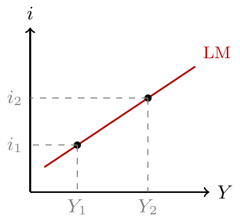

$\uparrow Y$ → demanda de dinero sube → con $\bar{M}$ fija, $i$ debe subir para restablecer el equilibrio → nuevo punto sobre la LM.

## Pendiente de la LM

La LM tiene **pendiente positiva** en el plano $(i, Y)$:

- $\uparrow Y$ → más transacciones → $\uparrow$ demanda de dinero
- Con oferta fija, el exceso de demanda presiona la tasa al alza
- El equilibrio requiere $\uparrow i$

**Desplazamientos de la LM:**

| Cambio | Efecto |
| --- | --- |
| BCCh $\uparrow \bar{M}$ (expansión monetaria) | LM se desplaza **a la derecha** → $\downarrow i$ para cada $Y$ |
| BCCh $\downarrow \bar{M}$ (contracción monetaria) | LM se desplaza **a la izquierda** → $\uparrow i$ para cada $Y$ |

**Conexión con Clase 02:** cuando el BCCh baja la TPM, está esencialmente desplazando la LM hacia la derecha — facilitando más dinero al sistema a menor costo.

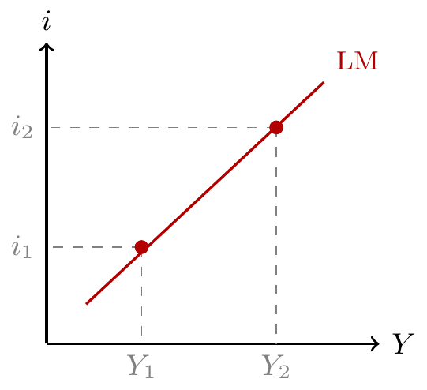

$\uparrow Y$ de $Y_1$ a $Y_2$ → mayor demanda de dinero → $i$ sube de $i_1$ a $i_2$

Un aumento de $\bar{M}$ desplaza la LM a la derecha.

## Movimiento sobre vs. desplazamiento de la LM

**Movimiento sobre la curva** — causa: $\uparrow Y$

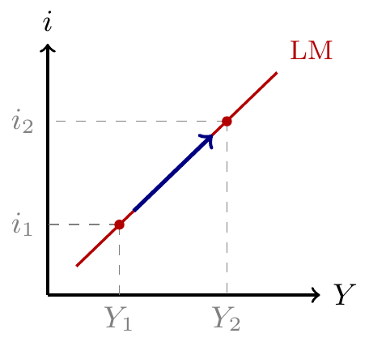

$Y\uparrow$ → más transacciones → $M^d\uparrow$ → $i$ sube **sobre** la misma LM.

**Desplazamiento de la curva** — causa: $\uparrow \bar{M}$

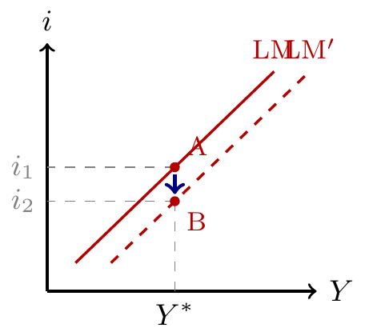

$\bar{M}\uparrow$ → exceso de oferta → $i$ baja para cada $Y$ → la LM **se desplaza** completa.

> Un cambio en $Y$ mueve **a lo largo** de la LM. Un cambio en $\bar{M}$ desplaza **la LM completa**.

# Equilibrio y Dinámica en el Modelo IS-LM

## El sistema IS-LM

El equilibrio macroeconómico requiere que **ambos mercados** estén en equilibrio simultáneamente:

$$IS: \quad Y = C(Y - T) + I(r) + G$$

$$LM: \quad \frac{\bar{M}}{P} = L(i, Y)$$

La solución del sistema determina el **par de equilibrio** $(Y^*, i^*)$: el nivel de producto y la tasa de interés que equilibran simultáneamente el mercado de bienes y el mercado monetario.

**Supuesto:** analizamos el caso de **economía cerrada** — la apertura al mundo modifica los resultados y se trata en `clase03_lectura_01_mundell_fleming`.

## Política monetaria expansiva (economía cerrada)

**Escenario:** el BCCh aumenta la masa monetaria ($\uparrow \bar{M}$).

**Mecanismo paso a paso:**

1. $\uparrow \bar{M}$ → LM se desplaza a la derecha (A → B)
2. En B, la tasa de interés baja: $\downarrow i$ → $\uparrow I(r)$
3. Mayor inversión → exceso de demanda de bienes → empresas des-acumulan inventarios → $\uparrow$ producción
4. Mayor producción → $\uparrow$ demanda de dinero → presiona tasa al alza
5. El sistema se estabiliza en C: **$\uparrow Y$, $\downarrow i$**

**Resultado:** la política monetaria expansiva aumenta el producto y baja la tasa de interés.

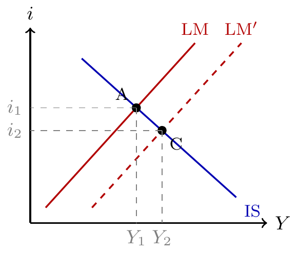

La LM se desplaza de LM a LM’. El nuevo equilibrio es C (mayor $Y$, menor $i$).

## Política fiscal expansiva (economía cerrada)

**Escenario:** el gobierno aumenta el gasto ($\uparrow G$).

**Mecanismo paso a paso:**

1. $\uparrow G$ → IS se desplaza a la derecha (A → B’)
2. En B’, hay exceso de demanda de bienes → $\uparrow$ producción
3. Mayor producción → $\uparrow$ demanda de dinero → $\uparrow i$
4. La tasa más alta frena parcialmente la inversión privada
5. El sistema se estabiliza en B: **$\uparrow Y$, $\uparrow i$**

**Crowding out parcial:** el $\uparrow i$ reduce $I$ privada, atenuando el efecto multiplicador. El producto sube, pero menos de lo que predice el modelo Keynesiano simple.

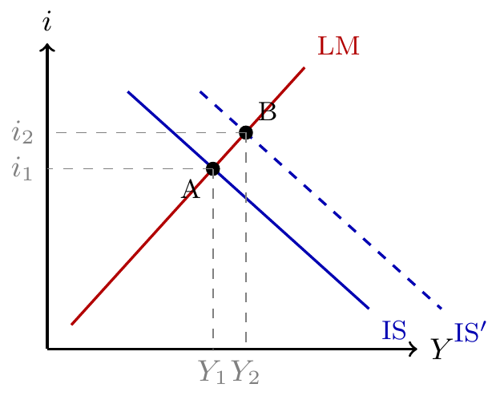

La IS se desplaza a la derecha. El nuevo equilibrio es B (mayor $Y$ e $i$).

## Policy mix: la interacción entre PM y PF

Dos lecciones sobre la combinación de políticas:

1. **El efecto depende del instrumento:** la PM expansiva baja $i$ y aumenta la participación de la inversión privada en el gasto total; la PF expansiva sube $i$ y aumenta la participación del gasto público.
2. **Trade-off de estabilización:** si se quiere estabilizar el PIB, una PF expansiva debe compensarse con una PM contractiva (y viceversa), para no generar ni inflación ni recesión.

**Chile 2025-2026: el policy mix real**

| Instrumento | Dirección | Dato |
| --- | --- | --- |
| TPM (BCCh) | Expansiva — ciclo de baja desde 2024 | TPM bajó de 11,25% (peak 2022) |
| Balance Estructural (Fisco) | Contractiva necesaria — reducir desvío | BE 2025: -3,6% del PIB (meta: -1,1%) |

El gobierno necesita reducir el déficit (PF contractiva) mientras el BCCh sigue bajando tasas (PM expansiva). En términos IS-LM: IS se desplaza a la izquierda y LM a la derecha — el $Y$ puede mantenerse si las magnitudes se coordinan, pero la composición del gasto cambia.

## Trampa de liquidez

Existe un caso límite en que la **política monetaria pierde efectividad**: la trampa de liquidez.

Ocurre cuando la tasa de interés nominal está **cerca de cero** — su piso absoluto. A ese nivel, el costo de oportunidad de tener dinero en efectivo es nulo, por lo que el público absorbe cualquier aumento de $\bar{M}$ sin que la tasa baje más.

**La LM se vuelve horizontal**: cualquier expansión monetaria no reduce $i$ → no estimula la inversión → no sube el producto.

**Casos reales:**

| País | Período | Respuesta |
| --- | --- | --- |
| Japón | 1990s–2010s | QE masivo, tasas negativas — sin efecto sostenido en demanda |
| EE.UU. | 2008–2015, 2020–2021 | Tasa Fed 0–0,25%, balance Fed ×8 |
| Zona Euro | 2014–2022 | Tasas negativas aplicadas por el BCE |

## Resumen de efectos IS-LM (economía cerrada)

Complete la siguiente tabla con los efectos de cada política sobre la demanda agregada y la tasa de interés:

| Para $P$ dado | Expansión monetaria ($\uparrow \bar{M}$) | Aumento gasto fiscal ($\uparrow G$) | Aumento tributario ($\uparrow T$) |
| --- | --- | --- | --- |
| **Demanda agregada ($Y$)** |  |  |  |
| **Tasa de interés ($i$)** |  |  |  |

> Pista: recuerde el mecanismo de cada política. La expansión monetaria desplaza la LM; el gasto fiscal desplaza la IS; el alza tributaria reduce el ingreso disponible y también desplaza la IS, pero en sentido contrario al gasto.

> Actividad: Ver `clase03_actividad_01_efectos_islm` para la versión con espacio de trabajo y pauta.

## Ejercicio IS-LM en números

Considere la siguiente economía:

$$C = 0{,}8(Y - T), \quad I = 20 - 0{,}4i, \quad G = 10, \quad T = 20$$

$$M^S = 50, \quad M^D = (0{,}5Y - i) \cdot P$$

**Preguntas:**

A. Derive la curva IS B. Suponiendo $P = 2$, derive la curva LM C. Determine la tasa de interés de equilibrio $i^*$ y la demanda agregada $Y^*$ D. ¿Qué ocurre si el gobierno aumenta el gasto a $G = 15$? ¿Y si el BCCh aumenta $M^S$ a 80?

> Resuelva en `clase03_actividad_02_islm`

# Cierre

## Volvamos al hilo conductor

“¿Puede Chile reaccionar a la guerra comercial de Trump con política fiscal o monetaria?”

Con el modelo IS-LM en economía **cerrada**, la respuesta sería sí — con matices:

- **PM expansiva:** baja $i$ → sube $I$ → sube $Y$ ✓
- **PF expansiva:** sube $G$ → sube $Y$, pero $\uparrow i$ genera crowding out parcial

Pero Chile es una **economía abierta** con tipo de cambio flexible y movilidad de capitales. En ese mundo, los resultados se invierten:

- **PF expansiva:** aprecia el tipo de cambio → bajan las exportaciones netas → el efecto se cancela (**inefectiva**)
- **PM expansiva:** deprecia el tipo de cambio → suben las exportaciones netas → **sí funciona**

La respuesta completa requiere el modelo Mundell-Fleming — disponible en `clase03_lectura_01_mundell_fleming`.

## Lo que conecta todo

Los conceptos de esta clase no son islas — forman una cadena:

```
Gasto autónomo (G, I, C̄)
        ↓
Multiplicador keynesiano → amplifica el impacto inicial
        ↓
Curva IS → equilibrio en mercado de bienes para cada tasa r
        ↓
Curva LM → equilibrio en mercado monetario (BCCh controla M̄)
        ↓
IS-LM → determina (Y*, i*) simultáneamente
        ↓
Policy mix → coordinación entre BCCh y Fisco
        ↓
Economía abierta → el tipo de cambio transforma los resultados
```

## Fechas relevantes

| Actividad | Detalle |
| --- | --- |
| Clase 1 | Generación de grupos |
| Clase 2 | Caso formativo en clases |
| Clase 3 | — |
| Clase 4 | Caso sumativo en clases |

## Fuentes y referencias

- Blanchard, O. (2017). *Macroeconomics* (7ª ed.). Pearson. Caps. 5 (IS-LM) y 19 (Mundell-Fleming).
- Banco Central de Chile. (2026, enero). *Informe de Política Monetaria*. bcentral.cl
- CFA. (2026, 26 mar.). *Informe de Balance Estructural y nivel prudente de deuda, 4T25*. cfachile.cl
- Mankiw, N. G. (2021). *Principios de Economía* (8ª ed.). Cengage. Cap. 34 (IS-LM).
- Modigliani, F. (1966). The life cycle hypothesis of saving. *American Economic Review*, 56(1/2), 160–217.
- Friedman, M. (1957). *A Theory of the Consumption Function*. Princeton University Press.